# Respondent

# 1 Description of DataSchema variable

The description of harmonised variables is the following:

- Short name: `respondent`
- Variable label: `Type of respondent`
- Variable description: `Type of respondent: participant, spouse or other.`
- Domain: `Other administrative variables`
- Value type: `categorical`
- Category coding:

| **Code** | **Category Label** |
| --- | --- |
| 0 | participant |
| 1 | spouse |
| 2 | other |

- Category missings:

| **Code** | **Category Label** |
| --- | --- |
| 991 | CAPI/interviewer error |
| 992 | Impute |
| 993 | Disable to measure |
| 994 | Not attempt/not done |
| 995 | Does not answer |
| 996 | Not applicable |
| 997 | Refuse |
| 998 | Do not know |
| 999 | Missing |

# 2 Data process

## 2.1 England

### 2.1.1 Wave 1

#### 2.1.1.1 Study-specific variable description

| **Name** | `finstat` |
| --- | --- |
| **Label** | `Post-field final type of sample member (including cohort number added)` |
| **Table name** | `wave_1_core_data_v3` |
| **Categories** | `text` |

Type of respondent

| Sample size | Missing values |
| --- | --- |
| 12099 | 0 |

Category

|  | C1CM | C1NP1 | C1YP |
| --- | --- | --- | --- |
| Frequency | 11391.00 | 72.0 | 636.00 |
| Percentage | 94.15 | 0.6 | 5.26 |

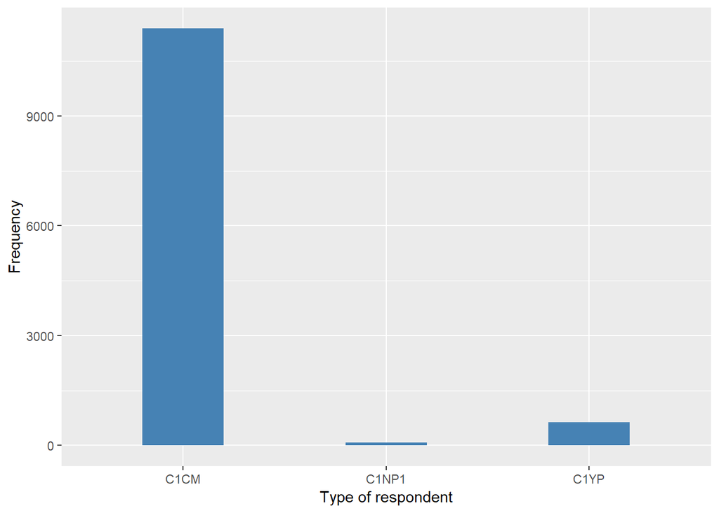

#### 2.1.1.2 Harmonisation algorithm

To compute the harmonized variable from the study-specific variable it has to be recoded as follows:

- `recode C1CM into 0 (participant)`
- `recode C1YP into 1 (spouse)`
- `recode C1NP1 into 1 (spouse)`

**R script:**

```r
ELSA_ds_w1 <- tibble(id = elsa_resp$id)
ELSA_ds_w1$respondent <- car::recode(elsa_resp$finstat, "'C1CM'=0; 'C1YP'=1; 'C1NP1'=1; NA=999")
ELSA_ds_w1$respondent <- labelled(ELSA_ds_w1$respondent, labels = cat_label)
label(ELSA_ds_w1$respondent) <- ds_label
```

#### 2.1.1.3 Statistical description of the new harmonised variable

Type of respondent

| Sample size | Missing values |
| --- | --- |
| 12099 | 0 |

Category

|  | 0 | 1 |
| --- | --- | --- |
| Frequency | 11391.00 | 708.00 |
| Percentage | 94.15 | 5.85 |

Type of missing

|  | 991 | 992 | 993 | 994 | 995 | 996 | 997 | 998 | 999 | NA |
| --- | --- | --- | --- | --- | --- | --- | --- | --- | --- | --- |
| Frequency | 0 | 0 | 0 | 0 | 0 | 0 | 0 | 0 | 0 | 0 |
| Percentage | 0 | 0 | 0 | 0 | 0 | 0 | 0 | 0 | 0 | 0 |

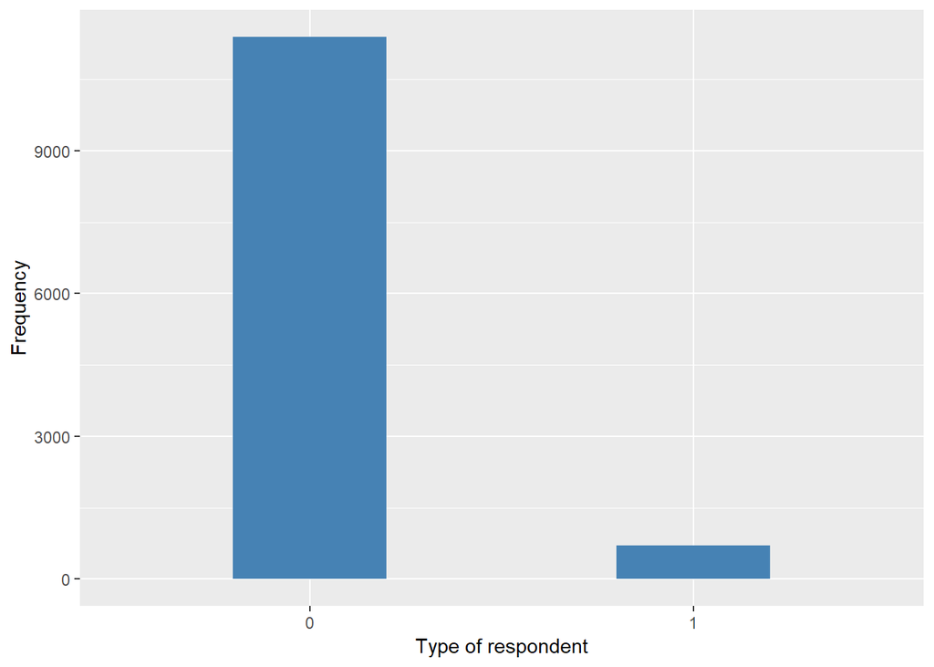

### 2.1.2 Wave 2

#### 2.1.2.1 Study-specific variable description

| **Name** | `sampsta` |
| --- | --- |
| **Label** | `Type of sample member (i.e. core member, core partner, younger partner or new partner)` |
| **Table name** | `wave_2_core_data_v4` |
| **Categories** | `1 = CM (core member)` |
|  | `2 = CP (core partner)` |
|  | `3 = YP (younger ptn)` |
|  | `4 = NP1 (new ptn from W1)` |
|  | `5 = NP2 (new ptn from W2)` |
| **Missing categories** | `-9 = Refusal` |
|  | `-8 = Don't know` |
|  | `-1 = Not applicable` |

Type of respondent

| Sample size | Missing values |
| --- | --- |
| 9432 | 0 |

Category

|  | 1 | 2 | 3 | 4 | 5 |
| --- | --- | --- | --- | --- | --- |
| Frequency | 8780.00 | 57.0 | 501.00 | 56.00 | 38.0 |
| Percentage | 93.09 | 0.6 | 5.31 | 0.59 | 0.4 |

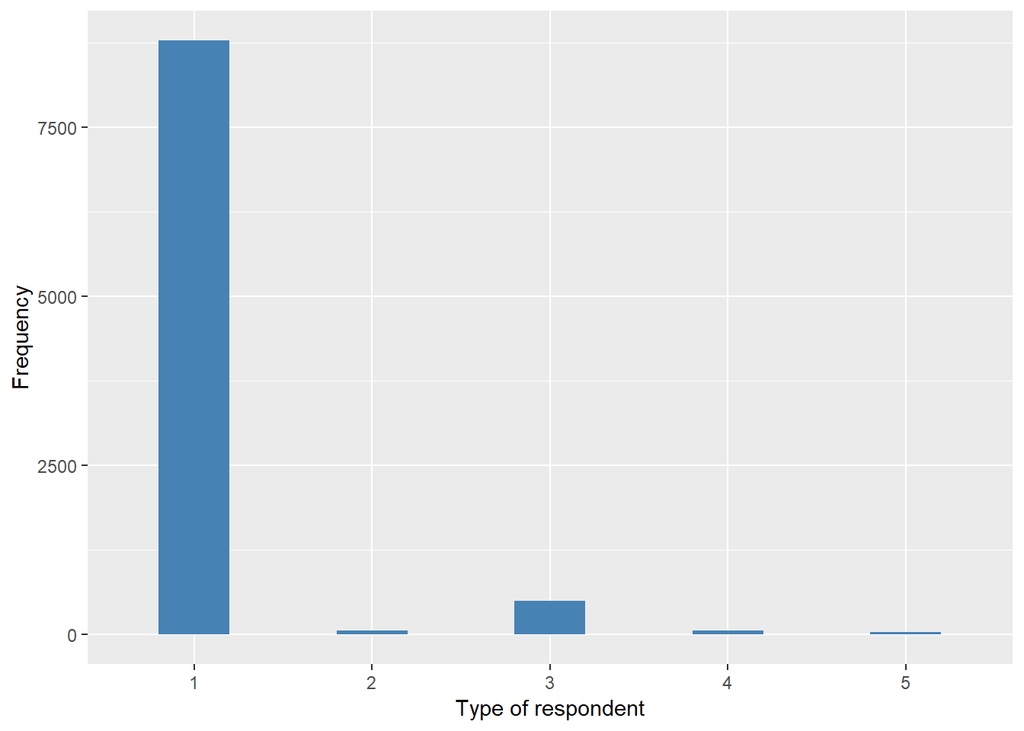

#### 2.1.2.2 Harmonisation algorithm

To compute the harmonized variable from the study-specific variable it has to be recoded as follows:

- `recode 1 into 0 (participant)`
- `recode 2 into 1 (spouse)`
- `recode 3 into 1 (spouse)`
- `recode 4 into 1 (spouse)`
- `recode 5 into 1 (spouse)`

**R script:**

```r
ELSA_ds_w2 <- tibble(id = elsa_resp$id)
ELSA_ds_w2$respondent <- car::recode(elsa_resp$sampsta, "1=0; 2=1; 3=1; 4=1; 5=1; NA=999")
ELSA_ds_w2$respondent <- labelled(ELSA_ds_w2$respondent, labels = cat_label)
label(ELSA_ds_w2$respondent) <- ds_label
```

#### 2.1.2.3 Statistical description of the new harmonised variable

Type of respondent

| Sample size | Missing values |
| --- | --- |
| 9432 | 0 |

Category

|  | 0 | 1 |
| --- | --- | --- |
| Frequency | 8780.00 | 652.00 |
| Percentage | 93.09 | 6.91 |

Type of missing

|  | 991 | 992 | 993 | 994 | 995 | 996 | 997 | 998 | 999 | NA |
| --- | --- | --- | --- | --- | --- | --- | --- | --- | --- | --- |
| Frequency | 0 | 0 | 0 | 0 | 0 | 0 | 0 | 0 | 0 | 0 |
| Percentage | 0 | 0 | 0 | 0 | 0 | 0 | 0 | 0 | 0 | 0 |

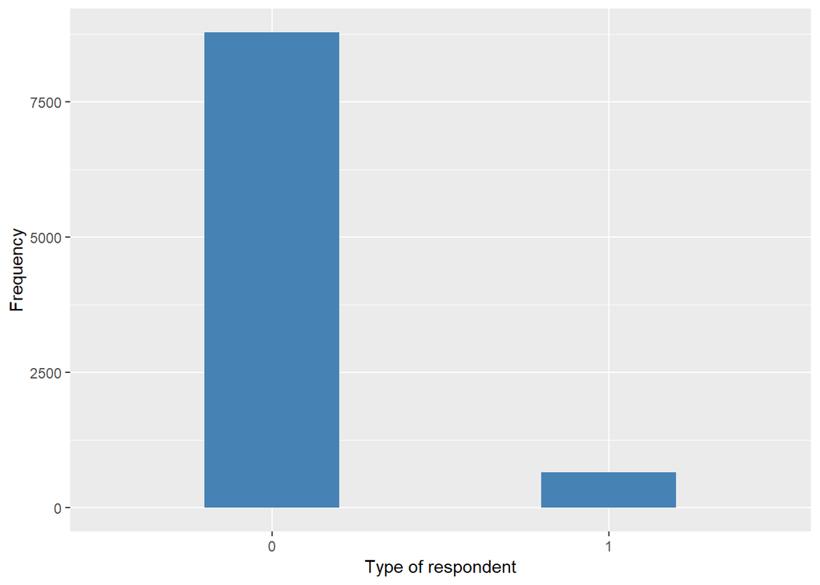

### 2.1.3 Wave 3

#### 2.1.3.1 Study-specific variable description

| **Name** | `sampsta` |
| --- | --- |
| **Label** | `Type of sample member (i.e. core member, core partner, younger partner or new partner)` |
| **Table name** | `wave_2_core_data_v4` |
| **Categories** | `1 = CM (core member)` |
|  | `2 = CP (core partner)` |
|  | `3 = YP (younger partner)` |
|  | `4 = NP1 (new partner from Wave 1)` |
|  | `5 = NP2 (new partner from Wave 2)` |
|  | `6 = NP3 (new partner from Wave 3)` |
|  | `7 = Potential CM` |
|  | `8 = Potential YP` |
|  | `9 = Potential OP (older partner)` |
|  | `10 = Not issued at Wave 3 sampling - see User Guide` |

Type of respondent

| Sample size | Missing values |
| --- | --- |
| 9771 | 0 |

Category

|  | 1 | 2 | 3 | 4 | 5 | 6 | 7 | 8 | 9 | 10 |
| --- | --- | --- | --- | --- | --- | --- | --- | --- | --- | --- |
| Frequency | 7535.00 | 89.00 | 311.00 | 43.00 | 31.00 | 47.00 | 1276.00 | 294.00 | 142.00 | 3.00 |
| Percentage | 77.12 | 0.91 | 3.18 | 0.44 | 0.32 | 0.48 | 13.06 | 3.01 | 1.45 | 0.03 |

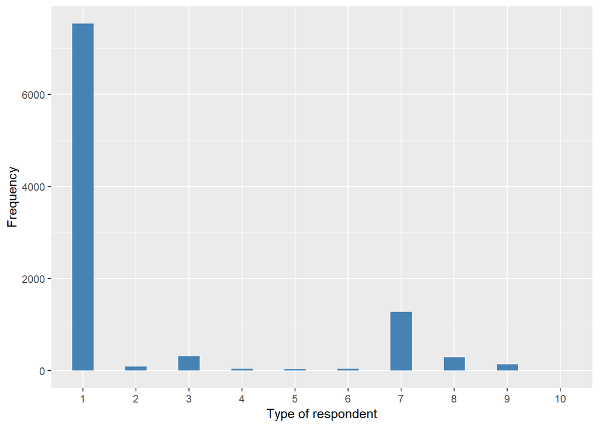

#### 2.1.3.2 Harmonisation algorithm

To compute the harmonized variable from the study-specific variable it has to be recoded as follows:

- `recode 1,7 into 0 (participant)`
- `recode 2-6 and 8-10 into 1 (spouse)`

**R script:**

```r
ELSA_ds_w3 <- tibble(id = elsa_resp$id)
ELSA_ds_w3$respondent <- car::recode(elsa_resp$sampsta, "1=0; 7=0; 2=1; 3=1; 4=1; 5=1; 6=1; 8=1; 9=1; 10=1; NA=999")
ELSA_ds_w3$respondent <- labelled(ELSA_ds_w3$respondent, labels = cat_label)
label(ELSA_ds_w3$respondent) <- ds_label
```

#### 2.1.3.3 Statistical description of the new harmonised variable

Type of respondent

| Sample size | Missing values |
| --- | --- |
| 9771 | 0 |

Category

|  | 0 | 1 |
| --- | --- | --- |
| Frequency | 8811.00 | 960.00 |
| Percentage | 90.18 | 9.82 |

Type of missing

|  | 991 | 992 | 993 | 994 | 995 | 996 | 997 | 998 | 999 | NA |
| --- | --- | --- | --- | --- | --- | --- | --- | --- | --- | --- |
| Frequency | 0 | 0 | 0 | 0 | 0 | 0 | 0 | 0 | 0 | 0 |
| Percentage | 0 | 0 | 0 | 0 | 0 | 0 | 0 | 0 | 0 | 0 |

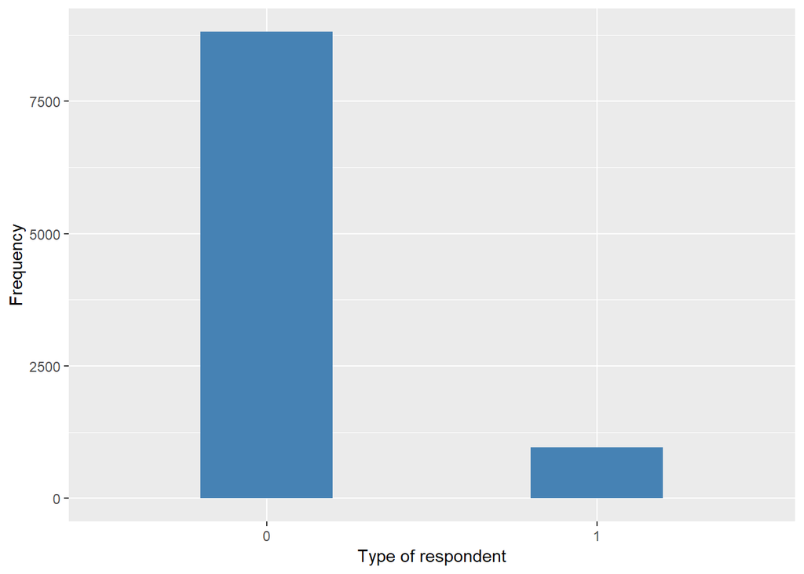

### 2.1.4 Wave 4

#### 2.1.4.1 Study-specific variable description

| **Name** | `finstat4` |
| --- | --- |
| **Label** | `Final status after Wave 4 interview` |
| **Table name** | `wave_4_elsa_data_v3` |
| **Categories** | `C1CM` |
|  | `C1CP` |
|  | `C1NP1` |
|  | `C1NP2` |
|  | `C1NP3` |
|  | `C1NP4` |
|  | `C1YP` |
|  | `C3CM` |
|  | `C3CP` |
|  | `C3NP3` |
|  | `C3NP4` |
|  | `C3OP` |
|  | `C3YP` |
|  | `C4CM` |
|  | `C4NP4` |
|  | `C4OP` |
|  | `C4YP` |

Type of respondent

| Sample size | Missing values |
| --- | --- |
| 11050 | 0 |

Category

|  | C1CM | C1CP | C1NP1 | C1NP2 | C1NP3 | C1NP4 | C1YP | C3CM | C3CP | C3NP3 | C3NP4 | C3OP | C3YP | C4CM | C4NP4 | C4OP | C4YP |
| --- | --- | --- | --- | --- | --- | --- | --- | --- | --- | --- | --- | --- | --- | --- | --- | --- | --- |
| Frequency | 6623.00 | 101.00 | 43.00 | 29.00 | 26.00 | 21.00 | 276.0 | 972.0 | 12.00 | 14.00 | 11.0 | 106.00 | 226.00 | 2291.00 | 15.00 | 165.00 | 119.00 |
| Percentage | 59.94 | 0.91 | 0.39 | 0.26 | 0.24 | 0.19 | 2.5 | 8.8 | 0.11 | 0.13 | 0.1 | 0.96 | 2.05 | 20.73 | 0.14 | 1.49 | 1.08 |

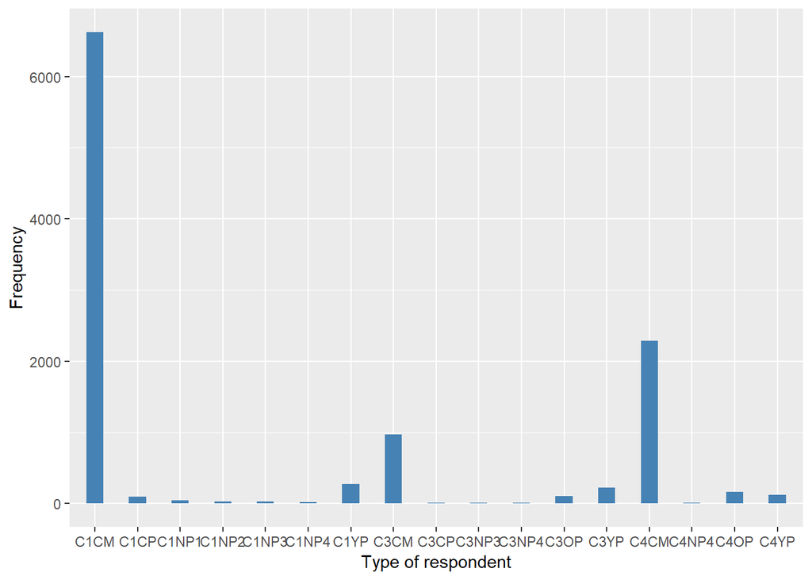

#### 2.1.4.2 Harmonisation algorithm

To compute the harmonized variable from the study-specific variable it has to be recoded as follows:

- `recode 'C1CM', C3CM and C4CM into 0 (participant)`
- `recode C1CP, C1NP1, C1NP2, C1NP3, C1NP4, C1YP, C3CP, C3NP3, C3NP4, C3OP, C3YP, C4NP4, C4OP and C4YP into 1 (spouse)`

**R script:**

```r
ELSA_ds_w4 <- tibble(id = elsa_resp$id)
ELSA_ds_w4$respondent <- car::recode(elsa_resp$finstat4, "'C1CM'=0; 'C3CM'=0; 'C4CM'=0; 'C1CP'=1; 'C1NP1'=1; 'C1NP2'=1; 'C1NP3'=1; 'C1NP4'=1; 'C1YP'=1; 'C3CP'=1; 'C3NP3'=1; 'C3NP4'=1; 'C3OP'=1; 'C3YP'=1; 'C4NP4'=1; 'C4OP'=1; 'C4YP'=1; NA=999")
ELSA_ds_w4$respondent <- labelled(ELSA_ds_w4$respondent, labels = cat_label)
label(ELSA_ds_w4$respondent) <- ds_label
```

#### 2.1.4.3 Statistical description of the new harmonised variable

Type of respondent

| Sample size | Missing values |
| --- | --- |
| 11050 | 0 |

Category

|  | 0 | 1 |
| --- | --- | --- |
| Frequency | 9886.00 | 1164.00 |
| Percentage | 89.47 | 10.53 |

Type of missing

|  | 991 | 992 | 993 | 994 | 995 | 996 | 997 | 998 | 999 | NA |
| --- | --- | --- | --- | --- | --- | --- | --- | --- | --- | --- |
| Frequency | 0 | 0 | 0 | 0 | 0 | 0 | 0 | 0 | 0 | 0 |
| Percentage | 0 | 0 | 0 | 0 | 0 | 0 | 0 | 0 | 0 | 0 |

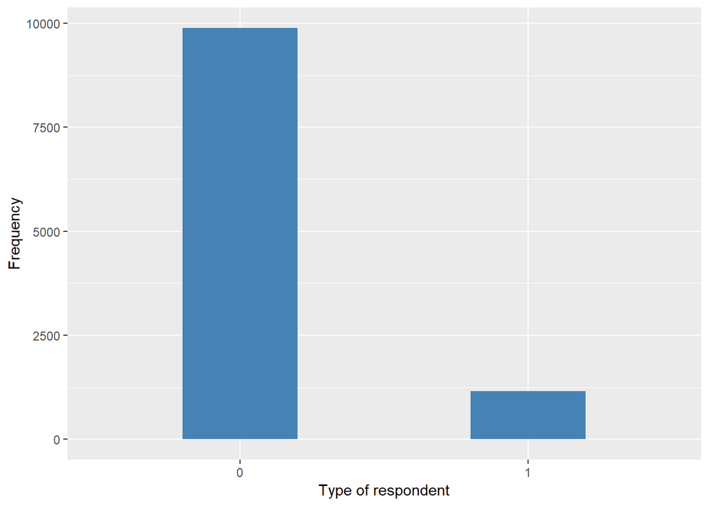

### 2.1.5 Wave 5

#### 2.1.5.1 Study-specific variable description

| **Name** | `samptyp` |
| --- | --- |
| **Label** | `Sampling status at Wave 5` |
| **Table name** | `wave_5_elsa_data_v4` |
| **Categories** | `text` |

Type of respondent

| Sample size | Missing values |
| --- | --- |
| 10274 | 0 |

Category

|  | -1 New partner, not known at time of sampling | CM | CP | NP | OP | SM | YP |
| --- | --- | --- | --- | --- | --- | --- | --- |
| Frequency | 32.00 | 9090.00 | 167.00 | 155.00 | 229.00 | 8.00 | 593.00 |
| Percentage | 0.31 | 88.48 | 1.63 | 1.51 | 2.23 | 0.08 | 5.77 |

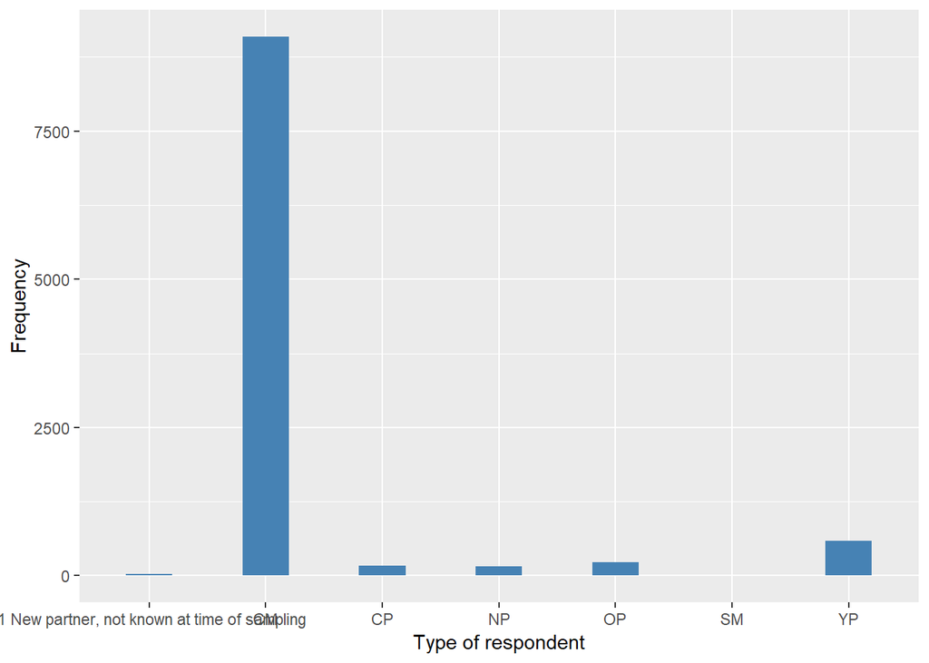

#### 2.1.5.2 Harmonisation algorithm

To compute the harmonized variable from the study-specific variable it has to be recoded as follows:

- `recode 'CM' into 0 (participant)`
- `recode '-1 New partner, not known at time of sampling', 'CP', 'NP', 'OP', and 'YP' into 1 (spouse)`
- `recode 'SM' into 2`

**R script:**

```r
ELSA_ds_w5 <- tibble(id = elsa_resp$id)
ELSA_ds_w5$respondent <- car::recode(elsa_resp$samptyp, "'CM'=0; '-1 New partner, not known at time of sampling'=1; 'CP'=1; 'NP'=1; 'OP'=1; 'YP'=1; 'SM'=2; NA=999")
ELSA_ds_w5$respondent <- labelled(ELSA_ds_w5$respondent, labels = cat_label)
label(ELSA_ds_w5$respondent) <- ds_label
```

#### 2.1.5.3 Statistical description of the new harmonised variable

Type of respondent

| Sample size | Missing values |
| --- | --- |
| 10274 | 0 |

Category

|  | 0 | 1 | 2 |
| --- | --- | --- | --- |
| Frequency | 9090.00 | 1176.00 | 8.00 |
| Percentage | 88.48 | 11.45 | 0.08 |

Type of missing

|  | 991 | 992 | 993 | 994 | 995 | 996 | 997 | 998 | 999 | NA |
| --- | --- | --- | --- | --- | --- | --- | --- | --- | --- | --- |
| Frequency | 0 | 0 | 0 | 0 | 0 | 0 | 0 | 0 | 0 | 0 |
| Percentage | 0 | 0 | 0 | 0 | 0 | 0 | 0 | 0 | 0 | 0 |

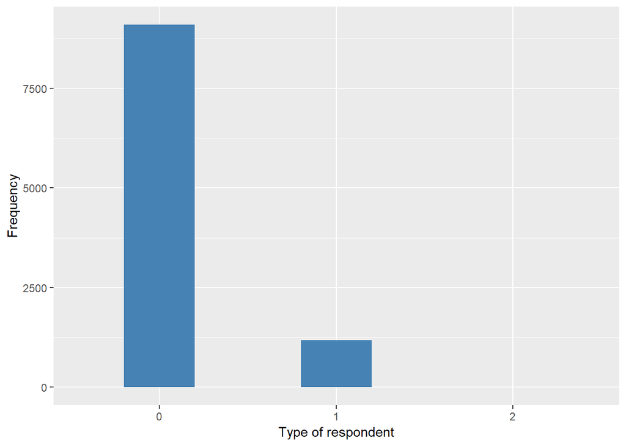

### 2.1.6 Wave 6

#### 2.1.6.1 Study-specific variable description

| **Name** | `idahhw6` |
| --- | --- |
| **Label** | `Analytical Wave 6 household serial number` |
| **Table name** | `wave_6_elsa_data_v2` |
| **Categories** | `1 = Core member` |
|  | `2 = Core partner` |
|  | `3 = New partner` |
|  | `4 = Younger partner` |
|  | `5 = Older partner` |
|  | `6 = Sample member` |
|  | `-1 = New partner, not known at time of sampling` |

Type of respondent

| Sample size | Missing values |
| --- | --- |
| 10601 | 0 |

Category

|  | -1 | 1 | 2 | 3 | 4 | 5 | 6 |
| --- | --- | --- | --- | --- | --- | --- | --- |
| Frequency | 30.00 | 9169.00 | 166.00 | 164.00 | 697.00 | 346.00 | 29.00 |
| Percentage | 0.28 | 86.49 | 1.57 | 1.55 | 6.57 | 3.26 | 0.27 |

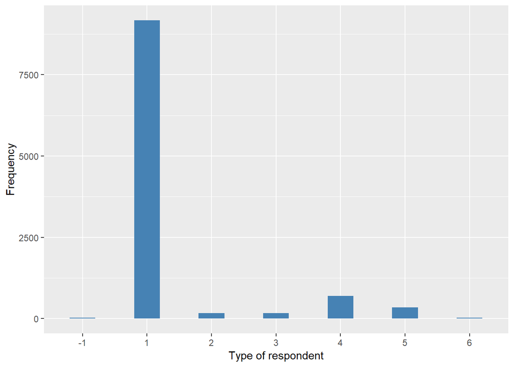

#### 2.1.6.2 Harmonisation algorithm

To compute the harmonized variable from the study-specific variable it has to be recoded as follows:

- `recode 1 into 0 (participant)`
- `recode -1 and 2-5 into 1 (spouse)`
- `recode 6 into 2`

**R script:**

```r
ELSA_ds_w6 <- tibble(id = elsa_resp$id)
ELSA_ds_w6$respondent <- car::recode(elsa_resp$samptyp, "1=0; -1=1; 2=1; 3=1; 4=1; 5=1; 6=2; NA=999")
ELSA_ds_w6$respondent <- labelled(ELSA_ds_w6$respondent, labels = cat_label)
label(ELSA_ds_w6$respondent) <- ds_label
```

#### 2.1.6.3 Statistical description of the new harmonised variable

Type of respondent

| Sample size | Missing values |
| --- | --- |
| 10601 | 0 |

Category

|  | 0 | 1 | 2 |
| --- | --- | --- | --- |
| Frequency | 9169.00 | 1403.00 | 29.00 |
| Percentage | 86.49 | 13.23 | 0.27 |

Type of missing

|  | 991 | 992 | 993 | 994 | 995 | 996 | 997 | 998 | 999 | NA |
| --- | --- | --- | --- | --- | --- | --- | --- | --- | --- | --- |
| Frequency | 0 | 0 | 0 | 0 | 0 | 0 | 0 | 0 | 0 | 0 |
| Percentage | 0 | 0 | 0 | 0 | 0 | 0 | 0 | 0 | 0 | 0 |

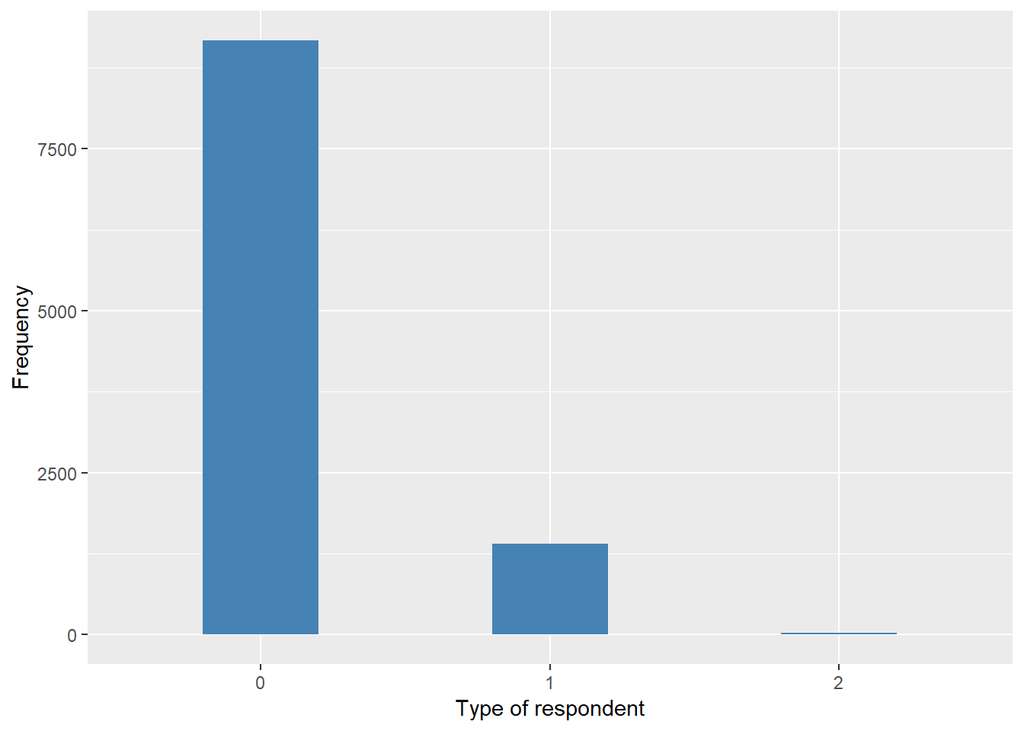

### 2.1.7 Wave 7

| **Name** | `samptyp` |
| --- | --- |
| **Label** | `Sampling status at Wave 7` |
| **Table name** | `wave_7_elsa_data` |
| **Categories** | `1 = Core member` |
|  | `2 = Core partner` |
|  | `3 = New partner` |
|  | `4 = Younger partner` |
|  | `5 = Older partner` |
|  | `6 = Sample member` |
|  | `-1 = New partner, not known at time of sampling` |

Type of respondent

| Sample size | Missing values |
| --- | --- |
| 9666 | 0 |

Category

|  | -1 | 1 | 2 | 3 | 4 | 5 |
| --- | --- | --- | --- | --- | --- | --- |
| Frequency | 28.00 | 8249.00 | 168.00 | 162.00 | 691.00 | 368.00 |
| Percentage | 0.29 | 85.34 | 1.74 | 1.68 | 7.15 | 3.81 |

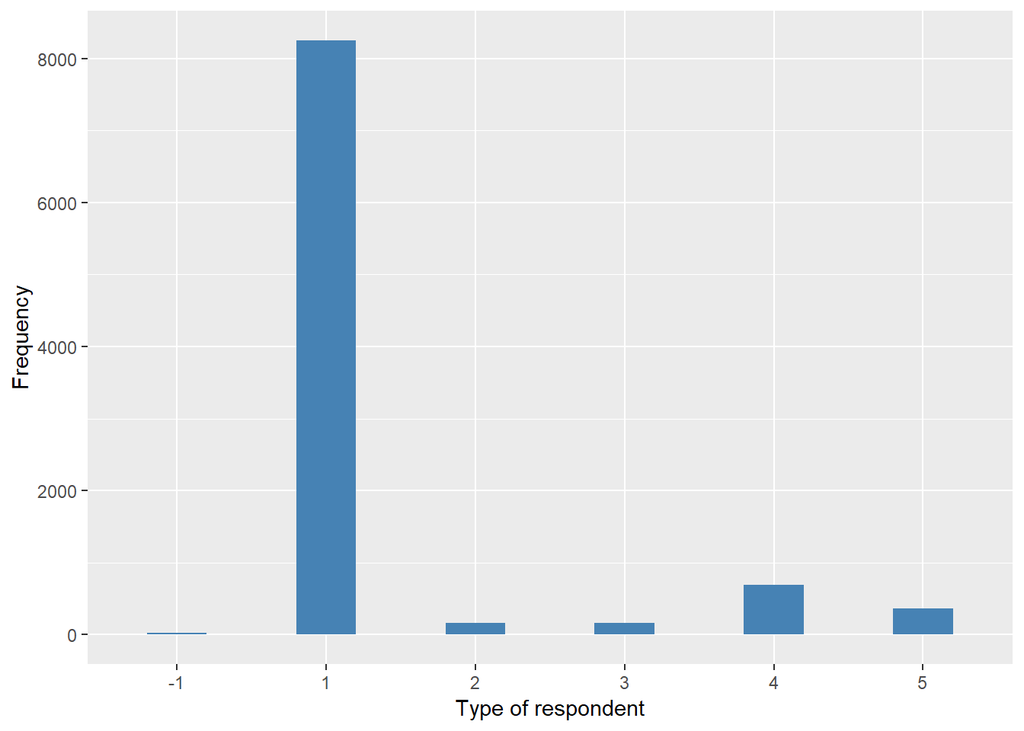

#### 2.1.7.1 Harmonisation algorithm

To compute the harmonized variable from the study-specific variable it has to be recoded as follows:

- `recode 1 into 0 (participant)`
- `recode -1 and 2-5 into 1 (spouse)`
- `recode 6 into 2`

**R script:**

```r
ELSA_ds_w7 <- tibble(id = elsa_resp$id)
ELSA_ds_w7$respondent <- car::recode(elsa_resp$samptyp, "1=0; -1=1; 2=1; 3=1; 4=1; 5=1; 6=2; NA=999")
ELSA_ds_w7$respondent <- labelled(ELSA_ds_w7$respondent, labels = cat_label)
label(ELSA_ds_w7$respondent) <- ds_label
```

#### 2.1.7.2 Statistical description of the new harmonised variable

Type of respondent

| Sample size | Missing values |
| --- | --- |
| 9666 | 0 |

Category

|  | 0 | 1 |
| --- | --- | --- |
| Frequency | 8249.00 | 1417.00 |
| Percentage | 85.34 | 14.66 |

Type of missing

|  | 991 | 992 | 993 | 994 | 995 | 996 | 997 | 998 | 999 | NA |
| --- | --- | --- | --- | --- | --- | --- | --- | --- | --- | --- |
| Frequency | 0 | 0 | 0 | 0 | 0 | 0 | 0 | 0 | 0 | 0 |
| Percentage | 0 | 0 | 0 | 0 | 0 | 0 | 0 | 0 | 0 | 0 |

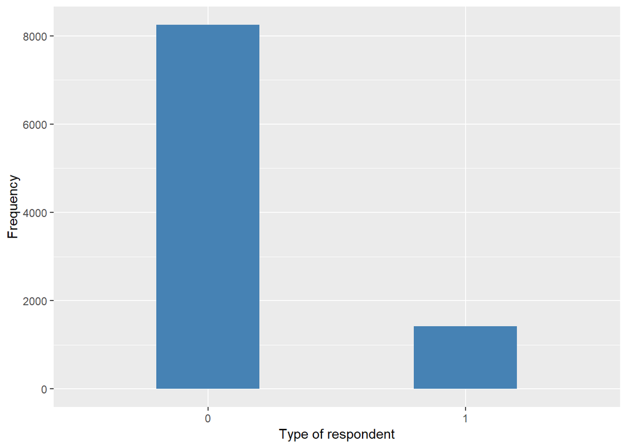

## 2.2 Summary of descriptive statistics of the harmonised variable accross populations and waves

Two tables are generated:

1. Percentages of categories in each harmonised variable.
2. Frequencies and percentages of individuals with different trajectories. To avoid too large table, Only trajectories with percentages larger than 0.3 are shown.

Type of respondent

| val | label | W1 | W2 | W3 | W4 | W5 | W6 | W7 |
| --- | --- | --- | --- | --- | --- | --- | --- | --- |
| 0 | participant | 94.15 | 93.09 | 90.18 | 89.47 | 88.48 | 86.49 | 85.34 |
| 1 | spouse | 5.85 | 6.91 | 9.82 | 10.53 | 11.45 | 13.23 | 14.66 |
| 2 | other | 0 | 0 | 0 | 0 | 0.08 | 0.27 | 0 |
| 991 | CAPI interviewer error | 0 | 0 | 0 | 0 | 0 | 0 | 0 |
| 992 | Impute | 0 | 0 | 0 | 0 | 0 | 0 | 0 |
| 993 | Disable to measure | 0 | 0 | 0 | 0 | 0 | 0 | 0 |
| 994 | Not attempt not done | 0 | 0 | 0 | 0 | 0 | 0 | 0 |
| 995 | Does not answer | 0 | 0 | 0 | 0 | 0 | 0 | 0 |
| 996 | Not applicable | 0 | 0 | 0 | 0 | 0 | 0 | 0 |
| 997 | Refuse | 0 | 0 | 0 | 0 | 0 | 0 | 0 |
| 998 | Do not know | 0 | 0 | 0 | 0 | 0 | 0 | 0 |
| 999 | Missing | 0 | 0 | 0 | 0 | 0 | 0 | 0 |
| NA | NA | 0 | 0 | 0 | 0 | 0 | 0 | 0 |
| n | sample size | 12099 | 9432 | 9771 | 11050 | 10274 | 10601 | 9666 |

|  | val | frq | raw.prc |
| --- | --- | --- | --- |
| 1 | 0000000 | 4106 | 22.21 |
| 2 | 000000NA | 659 | 3.56 |
| 3 | 00000NA0 | 66 | 0.36 |
| 4 | 00000NANA | 484 | 2.62 |
| 5 | 0000NA00 | 60 | 0.32 |
| 8 | 0000NANANA | 593 | 3.21 |
| 9 | 000NA000 | 107 | 0.58 |
| 10 | 000NA00NA | 60 | 0.32 |
| 16 | 000NANANANA | 897 | 4.85 |
| 17 | 00NA0000 | 107 | 0.58 |
| 32 | 00NANANANANA | 1199 | 6.48 |
| 33 | 0NA00000 | 93 | 0.50 |
| 46 | 0NA0NANANANA | 107 | 0.58 |
| 47 | 0NANA0000 | 70 | 0.38 |
| 55 | 0NANANA000 | 56 | 0.30 |
| 62 | 0NANANANANANA | 1963 | 10.62 |
| 63 | 1100000 | 72 | 0.39 |
| 73 | 1111111 | 203 | 1.10 |
| 100 | 11NANANANANA | 91 | 0.49 |
| 121 | 1NANANANANANA | 119 | 0.64 |
| 141 | NANA00000 | 618 | 3.34 |
| 142 | NANA0000NA | 81 | 0.44 |
| 148 | NANA00NANANA | 84 | 0.45 |
| 157 | NANA0NANANANA | 200 | 1.08 |
| 158 | NANA11111 | 247 | 1.34 |
| 173 | NANA1NANANANA | 105 | 0.57 |
| 174 | NANANA0000 | 1501 | 8.12 |
| 175 | NANANA000NA | 221 | 1.20 |
| 177 | NANANA00NANA | 149 | 0.81 |
| 181 | NANANA0NANANA | 284 | 1.54 |
| 182 | NANANA1111 | 208 | 1.12 |
| 189 | NANANA1NANANA | 81 | 0.44 |
| 190 | NANANANA111 | 66 | 0.36 |
| 198 | NANANANANA00 | 661 | 3.58 |
| 199 | NANANANANA0NA | 165 | 0.89 |
| 200 | NANANANANA11 | 284 | 1.54 |
| 201 | NANANANANA1NA | 97 | 0.52 |
| 204 | NANANANANANA0 | 301 | 1.63 |
| 205 | NANANANANANA1 | 208 | 1.12 |

# 3 Quality estimation

There are two variables per wave that has the same information. Some divergence were detected between those variables at waves 3 and 4.